# From Raw Data to Machine Learning in R

Hands-on workshop with real Alzheimer’s data (OASIS brain MRI dataset)

Author

Dany Mukesha

Published

today

# Welcome

no bioinformatics, statistics, or machine learning background assumed here. If you can run a line of R code, you can complete this workshop.

**What will you learn?** By the end you will have built, evaluated, and interpreted machine learning models that classify research subjects as *demented* or *nondemented* from real demographics, cognitive testing, and MRI brain measurements; and you will understand every step between the raw table and the prediction.

**The dataset.** The [OASIS-1 Cross-Sectional dataset](https://sites.wustl.edu/oasisbrains/home/oasis-1/) (Marcus et al., 2007; Washington University School of Medicine) contains brain MRI scans and clinical data from **436 adults aged 18–96**. For 235 of them; the older cohort, expert clinicians assigned a **Clinical Dementia Rating (CDR)**:

- 0 = nondemented,
- > 0 = demented.

Alongside each scan we have age, sex, education, socioeconomic status, the **MMSE** cognitive test score, and three MRI-derived brain-volume measures. The CSV is downloaded automatically from a public mirror; nothing needs to be installed by hand.

**How to run this document.** Open it in RStudio and click *Render*, or run the chunks one at a time with `Ctrl+Enter` (Cmd+Enter on Mac). Total runtime is about 1–2 minutes on a laptop.

```r
library(dplyr) # data manipulation (filter, select, group_by...)
library(tidyr) # also data manupulation (drop_na, ...)
library(ggplot2) # plotting
library(caret) # splitting, training, resampling
library(recipes) # preprocessing "recipes" applied inside CV
library(randomForest) # random forest model engine
library(glmnet) # penalized regression engine (used via caret)
library(pROC) # ROC curves and AUC

## library(tidyverse) # this is an eco-system of R programming, that we cover later.
```

# The big picture

Every supervised machine learning project follows the same arc:

> **Import → Clean → Explore → Split → Train → Evaluate → Interpret**

Three rules keep the results honest; we will apply all three:

1. **Split before you transform.** Any step that “learns” from the data (scaling, imputation, feature selection) must be fitted on training data only, otherwise information leaks from test data into training, *data leakage*, and performance looks better than it is.
2. **Touch the test set once, at the very end.** The test set simulates future patients. Peek at it repeatedly and it stops being a test.
3. **Start simple.** A plain logistic regression is the baseline; a fancier model must clearly beat it to earn its complexity.

# Step 1: Import the raw data

Rule: never modify the original file. We load it into R and work on a copy. If the CSV is already in your working folder we use it; otherwise we download it once from a public mirror.

```r
data_file <- "oasis_cross-sectional.csv"
if (!file.exists(data_file)) {
  download.file(
    url = paste0("https://raw.githubusercontent.com/jddunn/",
                 "dementia-progression-analysis/master/",
                 "oasis_cross-sectional.csv"),
    destfile = data_file
  )
}
raw_data <- read.csv(data_file, na.strings = c("N/A", ""))

cat("Raw data dimensions:", nrow(raw_data), "rows x", ncol(raw_data), "columns\n")
```

```
Raw data dimensions: 436 rows x 12 columns
```

```r
head(raw_data, 3)
```

```
             ID M.F Hand Age Educ SES MMSE CDR eTIV  nWBV   ASF Delay
1 OAS1_0001_MR1   F    R  74    2   3   29 0.0 1344 0.743 1.306    NA
2 OAS1_0002_MR1   F    R  55    4   1   29 0.0 1147 0.810 1.531    NA
3 OAS1_0003_MR1   F    R  73    4   3   27 0.5 1454 0.708 1.207    NA
```

436 subjects, 12 columns. Note `na.strings`: this file writes missing values as the text `"N/A"`, and without this argument R would treat them as text; a classic import trap.

Here is also a brief explanation of each feature

| Feature | Description |
| --- | --- |
| `ID` | Participant or scan identifier. |
| `M.F` | Sex: male or female. |
| `Hand` | Handedness: right or left. |
| `Age` | Age in years. |
| `Educ` | Education level or years of education, depending on coding. |
| `SES` | Socioeconomic status. |
| `MMSE` | Cognitive test score (0–30); higher scores indicate better cognition. |
| `CDR` | Dementia severity rating; higher scores indicate greater impairment. |
| `eTIV` | Estimated total intracranial volume. |
| `nWBV` | Normalized whole-brain volume. |
| `ASF` | MRI atlas scaling factor. |
| `Delay` | Time between visits or scans, usually in months. |

# Step 2: Clean and tidy

Real data is always messy. We drop columns that cannot predict anything, define the outcome, and keep the subjects who were actually tested.

```r
data <- raw_data |>
  select(-ID, -Hand, -Delay) |> # no signal, or no variation
  filter(!is.na(CDR)) |> # keep tested (older) subjects
  mutate(Dementia = factor(ifelse(CDR > 0, "demented", "nondemented"),
                           levels = c("demented", "nondemented"))) |>
  select(-CDR) # CDR is now the outcome itself

cat("Subjects with complete diagnostic testing:", nrow(data), "\n")
```

```
Subjects with complete diagnostic testing: 235
```

```r
cat("Age range:", range(data$Age), "years\n")
```

```
Age range: 33 96 years
```

Three quiet teaching points hide in that chunk:

- **`Hand` is dropped because everyone is right-handed.** A column with zero variation cannot help a model; always check for these.
- **`Delay` is dropped** it only describes scan logistics.
- **The outcome is derived, not given.** The file has no “diagnosis” column; we build it from the CDR. Deriving outcomes from clinical scales is everyday work in medical data science.

```r
cat("Missing values per column:\n")
```

```
Missing values per column:
```

```r
print(colSums(is.na(data)))
```

```
     M.F      Age     Educ      SES     MMSE     eTIV     nWBV      ASF
       0        0        0       19        0        0        0        0
Dementia
       0
```

Only `SES` (socioeconomic status) has missing values: 19 of 235 subjects (8%). Normally, we can *drop* rows with large % of missin value, here dropping 8% of patients would waste real data, so we **impute with the median** instead, and we will let the model pipeline do it *inside* cross-validation (Step 5), so no information leaks.

# Step 3: Explore the data (EDA)

Always look before you model. First: how balanced are the two classes?

```r
table(data$Dementia)
```

```
   demented nondemented
        100         135
```

100 demented vs 135 nondemented, mildly imbalanced, which is why we will use **stratified splitting** and **AUC** rather than plain accuracy.

Next: do the measurements differ between the two groups?

```r
data |>
  select(M.F) |>
  table()
```

```
M.F
  F   M
156  79
```

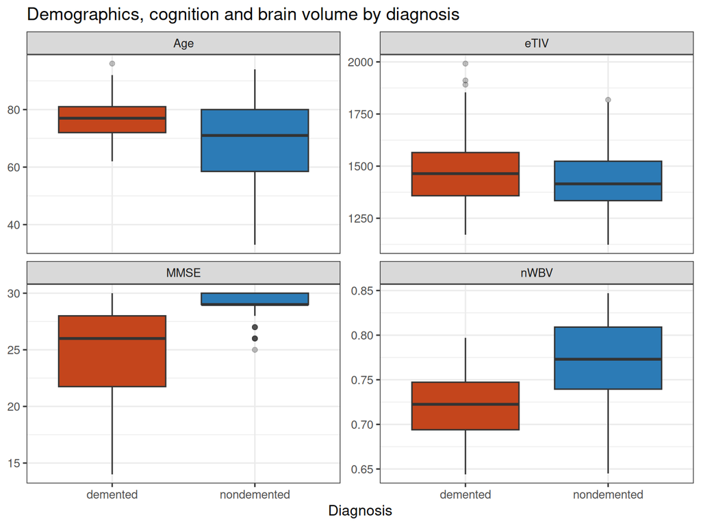

```r
plot_features <- c("Age", "MMSE", "nWBV", "eTIV")
eda_long <- data |>
  tidyr::pivot_longer(cols = all_of(plot_features),
                      names_to = "feature", values_to = "value")
ggplot(eda_long, aes(x = Dementia, y = value, fill = Dementia)) +
  geom_boxplot(outlier.alpha = 0.3) +
  facet_wrap(~ feature, scales = "free_y") +
  scale_fill_manual(values = c("demented"    = "#C4451C",
                               "nondemented" = "#2C7BB6")) +
  labs(title = "Demographics, cognition and brain volume by diagnosis",
       x = "Diagnosis", y = NULL) +
  theme_bw(base_size = 12) +
  theme(legend.position = "none")
```

What to notice:

- **MMSE** (cognitive test, 0–30): clearly lower in the demented group -> strong signal.
- **nWBV** (normalized whole-brain volume): smaller brains, more dementia -> the MRI biology showing up in the data.
- **Age**: demented subjects are older, on average.
- **eTIV** (total intracranial volume): much less separated -> head size is not the disease.

Finally, a correlation check:

```r
corr_mat <- cor(data |> select(where(is.numeric)), use = "complete.obs")
corr_mat |>
  round(2)
```

```
       Age  Educ   SES  MMSE  eTIV  nWBV   ASF
Age   1.00 -0.21  0.16 -0.31  0.04 -0.74 -0.03
Educ -0.21  1.00 -0.74  0.30  0.17  0.17 -0.14
SES   0.16 -0.74  1.00 -0.26 -0.18 -0.12  0.17
MMSE -0.31  0.30 -0.26  1.00 -0.01  0.48  0.02
eTIV  0.04  0.17 -0.18 -0.01  1.00 -0.21 -0.99
nWBV -0.74  0.17 -0.12  0.48 -0.21  1.00  0.22
ASF  -0.03 -0.14  0.17  0.02 -0.99  0.22  1.00
```

Two MRI features correlate at **r = -0.99** -> `ASF` is essentially a rescaled inverse of `eTIV`. Redundant features cause trouble for plain regression and motivate the *penalized* model we will train later.

**Click here to expand the section (Principal component analysis - PCA)**

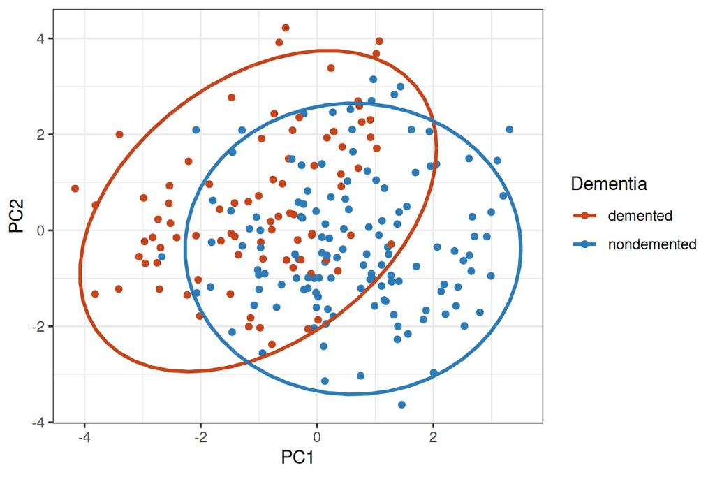

```r
vars <- c("Age", "Educ", "SES", "MMSE", "eTIV", "nWBV", "ASF")
df <- data |> drop_na(all_of(vars), Dementia)
pca <- prcomp(df |> select(all_of(vars)), scale. = TRUE)

scores <- as_tibble(pca$x[, 1:2]) |> mutate(Dementia = df$Dementia)

ggplot(scores, aes(PC1, PC2, color = Dementia)) +
  geom_point() +
  stat_ellipse(level = 0.95, linewidth = 1) +
  scale_color_manual(values = c("demented" = "#C4451C",
                               "nondemented" = "#2C7BB6")) +
  theme_bw()
```

# Step 4: Split: training vs test set

We keep 80% of subjects for model development and hold out 20% for the single final evaluation. The split is **stratified** -> it preserves the demented/nondemented ratio in both sets.

```r
set.seed(42)  # makes the random split reproducible for everyone
train_index <- createDataPartition(data$Dementia, p = 0.8, list = FALSE)
train_data  <- data[ train_index, ]
test_data   <- data[-train_index, ]

cat("Training set:", nrow(train_data), "subjects |",
    "Test set:", nrow(test_data), "subjects\n")
```

```
Training set: 188 subjects | Test set: 47 subjects
```

# Step 5: Define resampling and preprocessing

**Cross-validation (CV)** answers the question *“how well will this model work on subjects it has never seen?”* without touching the test set: the training data is split into 5 parts; the model trains on 4 and is evaluated on the 5th, repeated 5 times so every part is used for evaluation once.

```r
cv_control <- trainControl(
  method = "cv", # k-fold cross-validation
  number = 5, # k = 5
  classProbs = TRUE, # needed for ROC/AUC
  summaryFunction = twoClassSummary
)

preprocess_recipe <- recipe(Dementia ~ ., data = train_data) |>
  step_impute_median(all_numeric_predictors()) |> # fill NA in SES
  step_zv(all_numeric_predictors()) |> # drop zero-variance
  step_center(all_numeric_predictors()) |> # mean = 0
  step_scale(all_numeric_predictors()) # sd = 1
```

The **recipe** is a preprocessing *plan*, not a one-time transformation: caret re-executes it within each CV split, re-estimating the imputation medians and scaling values from that split’s training portion only. That is exactly what prevents data leakage (Rule 1) -> including for the SES imputation.

# Step 6: Train three candidate models

We compare three approaches of increasing complexity:

| Model | Idea | Interpretability |
| --- | --- | --- |
| Logistic regression | linear relationship between features and log-odds | high |
| Penalized regression (glmnet) | like above, but shrinks coefficients to handle correlated features | medium |
| Random forest | ensemble of decision trees; captures non-linear patterns | lower |

```r
set.seed(42)
model_glm <- train(
  preprocess_recipe, data = train_data,
  method = "glm", family = binomial,
  metric = "ROC", trControl = cv_control
)
```

```r
# caret picks the binomial family automatically for a two-class outcome.
set.seed(42)
model_glmnet <- train(
  preprocess_recipe, data = train_data,
  method = "glmnet",
  metric = "ROC", trControl = cv_control,
  tuneLength = 10
)
```

```r
set.seed(42)
model_rf <- train(
  preprocess_recipe, data = train_data,
  method = "rf",
  metric = "ROC", trControl = cv_control,
  tuneGrid = data.frame(mtry = c(2, 3, 4, 6))  # features tried per split
)
```

# Step 7: Compare models by cross-validated AUC

**AUC** (area under the ROC curve) is the probability that a random demented subject receives a higher risk score than a random nondemented one: 0.5 = coin flip, 1.0 = perfect ranking.

```r
cv_results <- resamples(list(
  `Logistic regression` = model_glm,
  `Penalized (glmnet)`  = model_glmnet,
  `Random forest`       = model_rf
))
round(summary(cv_results)$statistics$ROC[, "Mean", drop = FALSE], 3)
```

```
                     Mean
Logistic regression 0.892
Penalized (glmnet)  0.897
Random forest       0.899
```

AUC ≈ 0.89-0.90

realistic for clinical data. The differences between models are small.

# Step 8: Select the best model

```r
cv_means   <- sapply(list(model_glm, model_glmnet, model_rf),
                     function(m) max(m$results$ROC))
best_i     <- which.max(cv_means)
best_model <- list(model_glm, model_glmnet, model_rf)[[best_i]]
cat("Best model by CV AUC:", c("logistic regression", "penalized glmnet",
    "random forest")[best_i], sprintf("(CV AUC = %.3f)", cv_means[best_i]), "\n")
```

```
Best model by CV AUC: random forest (CV AUC = 0.899)
```

With differences this small, prefer the **simpler, more interpretable** model in practice; here the random forest edges out the others, but note in your own re-runs how sensitive this choice can be to the random split (Exercise 1).

# Step 9: Final evaluation on the test set (once!)

The moment of truth. The test set has played no role in any decision so far.

```r
pred_class <- predict(best_model, newdata = test_data)
pred_prob <- predict(best_model, newdata = test_data, type = "prob")[, 1]

confusionMatrix(pred_class, test_data$Dementia, positive = "demented")
```

```
Confusion Matrix and Statistics

             Reference
Prediction    demented nondemented
  demented          17           1
  nondemented        3          26

               Accuracy : 0.9149
                 95% CI : (0.7962, 0.9763)
    No Information Rate : 0.5745
    P-Value [Acc > NIR] : 2.953e-07

                  Kappa : 0.8236

 Mcnemar's Test P-Value : 0.6171

            Sensitivity : 0.8500
            Specificity : 0.9630
         Pos Pred Value : 0.9444
         Neg Pred Value : 0.8966
             Prevalence : 0.4255
         Detection Rate : 0.3617
   Detection Prevalence : 0.3830
      Balanced Accuracy : 0.9065

       'Positive' Class : demented
```

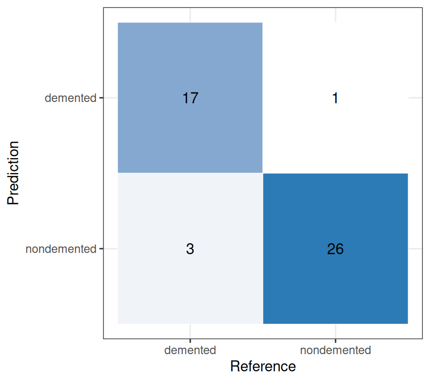

```r
cm <- as.data.frame(confusionMatrix(pred_class, test_data$Dementia,
                                    positive = "demented")$table)
colnames(cm) <- c("Prediction", "Reference", "Count")

ggplot(cm, aes(Reference, Prediction, fill = Count)) +
  geom_tile(color = "white") +
  geom_text(aes(label = Count), size = 4) +
  scale_x_discrete(limits = c("demented", "nondemented")) +
  scale_y_discrete(limits = rev(c("demented", "nondemented"))) +
  scale_fill_gradient(low = "white", high = "#2C7BB6") +
  guides(fill = "none") +
  theme_bw()
```

How to read the confusion matrix:

- **Sensitivity** (85%): of the truly demented subjects, how many did we catch? Missing a dementia diagnosis delays treatment and support.
- **Specificity** (96%): of the truly nondemented subjects, how many did we correctly leave alone? A false alarm causes anxiety and unnecessary follow-up.

```r
roc_obj <- roc(test_data$Dementia, pred_prob,
               levels = c("nondemented", "demented"), direction = "<")
cat(sprintf("Test-set AUC: %.3f (95%% CI %.3f-%.3f)\n",
            auc(roc_obj), ci.auc(roc_obj)[1], ci.auc(roc_obj)[3]))
```

```
Test-set AUC: 0.940 (95% CI 0.863-1.000)
```

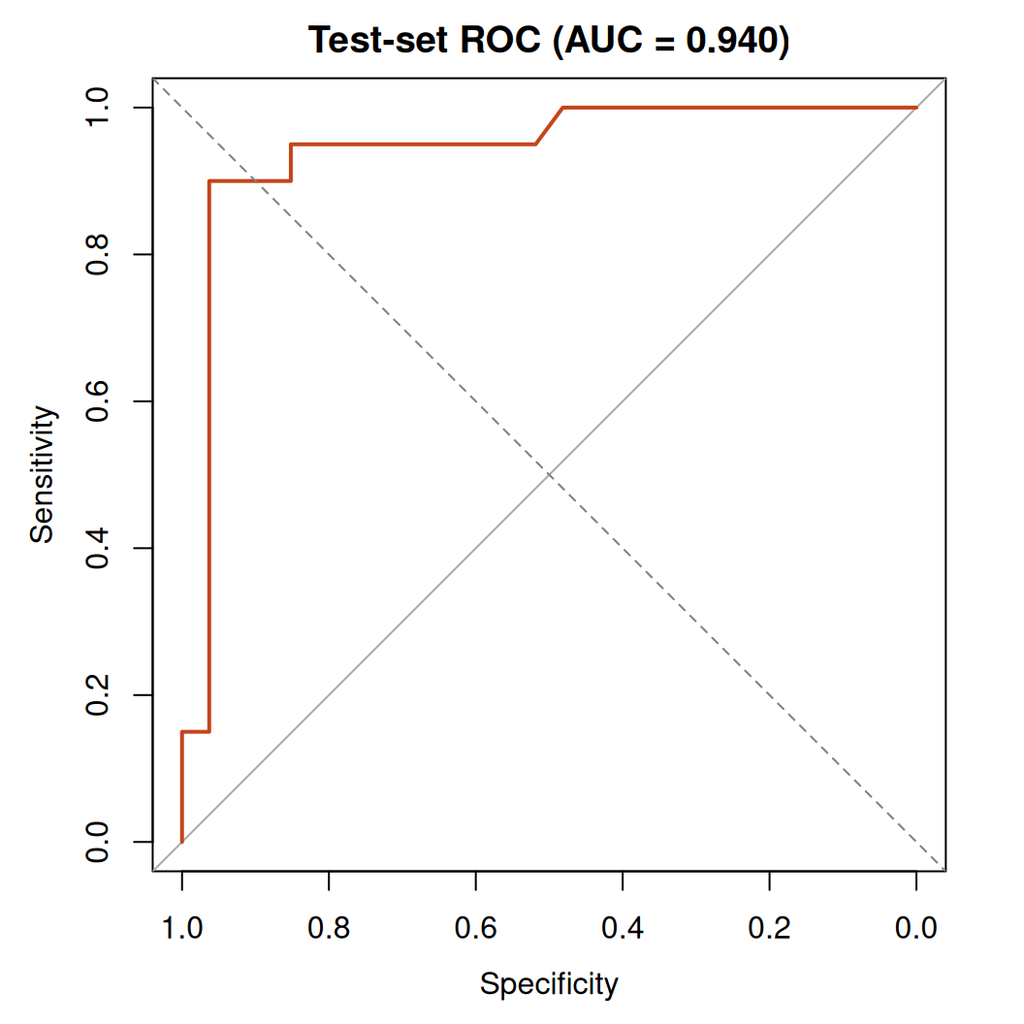

```r
plot(roc_obj, col = "#C4451C", lwd = 2,
     main = sprintf("Test-set ROC (AUC = %.3f)", auc(roc_obj)))
abline(a = 0, b = 1, lty = 2, col = "grey50")
```

**Click here to expand the section (ROC curve with ggplot2 and pROC pkgs)**

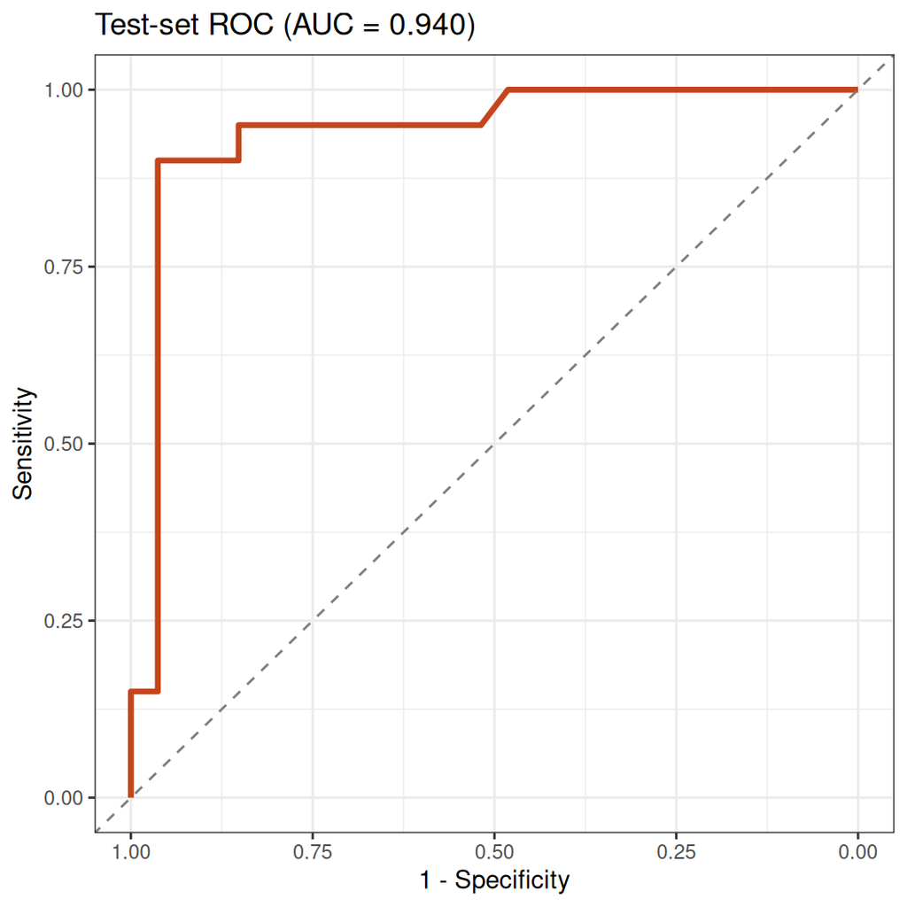

```r
roc_obj <- roc(test_data$Dementia, pred_prob,
               levels = c("nondemented", "demented"), direction = "<")

ggroc(roc_obj, color = "#C4451C", linewidth = 1.2) +
  geom_abline(slope = 1, intercept = 1, linetype = "dashed", color = "grey50") +
  labs(title = sprintf("Test-set ROC (AUC = %.3f)", auc(roc_obj)),
       x = "1 - Specificity", y = "Sensitivity") +
  theme_bw()
```

# Step 10: Interpret: what drives the prediction?

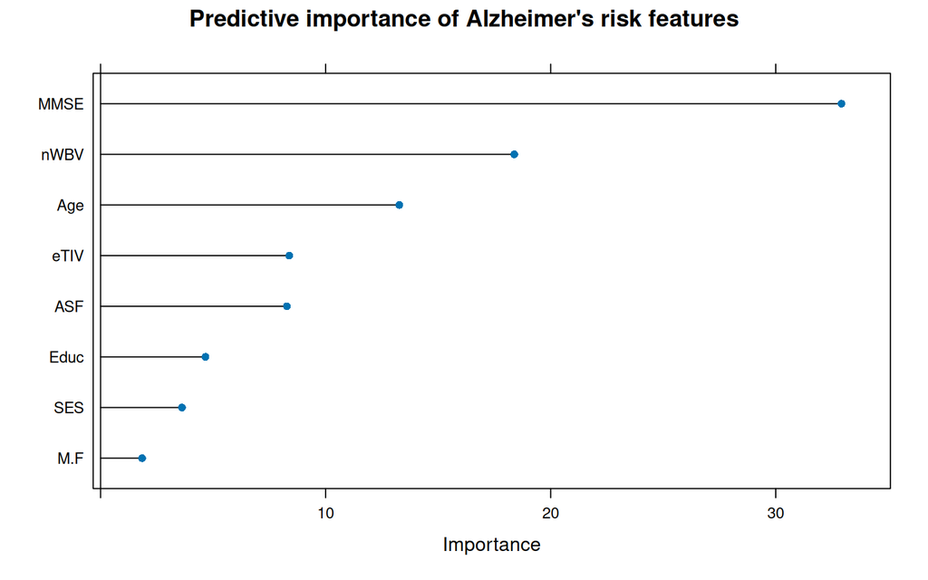

```r
varImp(best_model, scale = FALSE) |> plot(top = 8,
     main = "Predictive importance of Alzheimer's risk features")
```

**Click here to expand the section (feature important plot with ggplot2 pkg)**

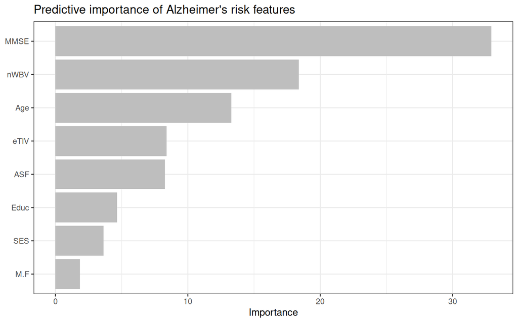

```r
importance <- varImp(best_model, scale = FALSE)$importance |>
  tibble::rownames_to_column("Feature") |>
  slice_max(order_by = Overall, n = 8)

ggplot(importance, aes(x = reorder(Feature, Overall), y = Overall)) +
  geom_col(fill = "grey") +
  coord_flip() +
  labs(title = "Predictive importance of Alzheimer's risk features",
       x = NULL, y = "Importance") +
  theme_bw()
```

**MMSE dominates**, and that deserves a critical pause. MMSE is a *cognitive test for dementia symptoms*: the model is partly predicting the diagnosis from a symptom score, which is circular-ish and less interesting scientifically than the question *“can brain volume predict dementia before symptoms?”* Try Exercise 4: remove MMSE and see how far MRI features alone get you. This, asking what a model’s inputs *mean*, is the most important interpretive habit in applied machine learning.

# Step 11: Save the model for future use

```r
# The saved object bundles preprocessing + model, so new subjects can be
# scored later with:  predict(readRDS("final_model.rds"), new_subjects)
saveRDS(best_model, "final_model.rds")
```

# Key takeaways

1. **The pipeline is the product.** Import → clean → explore → split → train → evaluate → interpret. Skipping the explore step is how people model garbage.
2. **Leakage is the #1 silent killer.** Impute, scale, and select features *inside* cross-validation (recipes make this easy), never before splitting.
3. **The test set is sacred.** One look, at the end.
4. **Real data gives realistic numbers.** AUC 0.94 on real clinical data is a good result, be suspicious of 0.99.
5. **Interrogate what the inputs mean.** A model that predicts dementia from a dementia symptom score has learned less than its AUC suggests.

# Exercises

1. Change `set.seed(42)` to another number and re-render. How much do the test-set metrics and the “best model” choice move? What does that tell you about a single 20% test split with only 235 subjects?
2. Drop the redundant feature (`select(-ASF)`) and rebuild. Does performance change? What about interpretability?
3. The 3 demented subjects we missed (false negatives) are the costly errors. Try `trainControl(..., sampling = "up")`; can sensitivity be improved without collapsing specificity?
4. (Advanced) Remove MMSE (`select(-MMSE)`) and rebuild. How far do age, demographics, and MRI features alone get you? Which MRI feature matters most now?

# References

- Marcus, D.S. et al. (2007). Open Access Series of Imaging Studies (OASIS): Cross-sectional MRI data in young, middle aged, nondemented, and demented older adults. *Journal of Cognitive Neuroscience* 19(9).
- Kuhn, M. (2008). Building predictive models in R using the caret package. *Journal of Statistical Software* 28(5).
- Data: [OASIS Brains, Washington University School of Medicine](https://sites.wustl.edu/oasisbrains/home/oasis-1/) (CSV mirrored on GitHub for workshop convenience).

Back to top